## Maximum likelihood

Consider a sample of data $y = (y_1,...,y_n)$, from a normal distribution. The likelihood of the data is given as,

$$L(\mu, \sigma) = \prod_{i=1}^n f(y_i \; ; \mu, \sigma)$$

where,

$$f(y_i \; ; \mu, \sigma) = \frac{ 1 }{ \sigma\sqrt{2\pi} } \exp\left\{ -\frac{ (y_i - \mu)^2 }{ 2\sigma^2 } \right\}$$

The log-likelihood is,

$$\ell(\mu, \sigma) = -\frac{n}{2} \log(2\pi) - n\log(\sigma) - \frac{1}{2\sigma^2} \sum_{i=1}^n (y_i-\mu)^2$$

The partial derivatives are,

$$\frac{\partial \ell}{\partial \mu} = \frac{1}{\sigma^2} \sum_{i=1}^n(y_i - \mu) \implies \hat{\mu} = \bar{y}$$

$$\frac{\partial \ell}{\partial \sigma} = -\frac{n}{\sigma} + \frac{1}{\sigma^3} \sum_{i=1}^n (y_i-\mu)^2 \implies \hat{\sigma} = \sqrt{\frac{1}{n}\sum_{i=1}^n(y_i-\bar{y})^2}$$

To check that the estimates are MLEs, make sure that the Hessian matrix evaluated at the MLEs is negative definite,

$$H = \left.\ell''(\theta) \right\rvert_{\theta = \hat{\theta}}
= \left. \frac{\partial^2}{\partial\theta^2} \ell(\theta) \right\rvert_{\theta = \hat{\theta}}
= \left. \begin{pmatrix} \frac{\partial^2\ell}{\partial\mu^2} & \frac{\partial^2\ell}{\partial\mu\partial\sigma } \\ \frac{\partial^2\ell}{\partial\mu\partial\sigma} & \frac{\partial^2\ell}{\partial\sigma^2} \end{pmatrix} \right\rvert _{\hat{\mu}, \hat{\sigma}}$$

### Example: New Haven annual temperatures

```r
suppressMessages(require(datasets))
data(nhtemp)

L = 30
mu = seq(50, 53, length = L)
sigma = seq(0.5, 2, length = L)
loglik.func = function(y, theta) sum(dnorm(y, theta[1], theta[2], log = TRUE))
loglik = matrix(apply(expand.grid(mu, sigma), 1, function(x) loglik.func(nhtemp,x)), L)
loglik[which(loglik < -140, arr.ind = TRUE)] = NA

# MLEs
opt = optim(f = loglik.func, y = nhtemp, par = c(50,0.5), lower = c(-Inf, 0), method = "L-BFGS-B", hessian = TRUE, control = list(fnscale = -1))

# check estimates
# matrixcalc::is.negative.definite(opt$hessian)
```

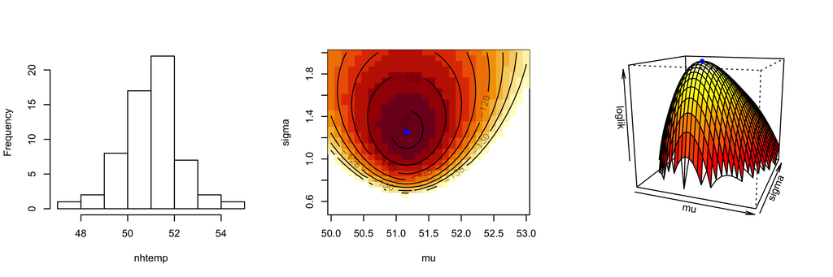

```r
# histogram
par(mfrow = c(1,3))
hist(nhtemp, main = "")

# heat map
image(mu, sigma, loglik, xlab = "mu", ylab = "sigma")
contour(mu, sigma, loglik, add = TRUE)
points(opt$par[1], opt$par[2], pch = 19, col = 4)

# 3d surface
# persp(mu, sigma, loglik, theta = 20, d = 2)
zfacet <- loglik[-1, -1] + loglik[-1, -ncol(loglik)] + loglik[-nrow(loglik), -1] + loglik[-nrow(loglik), -ncol(loglik)]
res = persp(mu, sigma, loglik, col = heat.colors(10)[cut(zfacet, 10)], theta = 20, d = 2, ltheta = 50, shade = 0.25)
points(trans3d(opt$par[1], opt$par[2], opt$value, pmat = res), col = 4, pch = 16)
```

### Numerical maximisation

This typically uses the Newton-Raphson method.

The second order Taylor series approximation of $\ell(\theta)$ around $\hat{\theta}_j$ is given by,

$$q(\theta) = \ell(\hat{\theta}_j) + \ell'(\hat{\theta}_j)(\theta-\hat{\theta}_j) + \frac{1}{2}\ell''(\hat{\theta}_j)(\theta-\hat{\theta}_j)^2$$

The maximum of the quadratic is found by setting the first derivative to zero and solving for $\theta$,

$$q'(\theta) = \ell'(\hat{\theta}_j) + \ell''(\hat{\theta}_j)(\theta-\hat{\theta}_j)$$

$$\implies \hat{\theta}_{j+1} = \hat{\theta}_j - \frac{ \ell'(\hat{\theta}_j) }{ \ell''(\hat{\theta}_j) }$$

### Fisher information

This is the negative of the second derivative of the likelihood, with respect to the parameter vector $\theta$, evaluated at the maximum likelihood estimates $\hat{\theta}$.

$$\mathcal{I}(\theta) = -\left.\mbox{E}\left[ \frac{ \partial^2 }{ \partial \theta^2 } \ell(\theta) \right] \right\rvert_{\theta = \widehat{\theta}}$$

If there are $p$ parameters, then the Fisher information is a $p$ by $p$ matrix

The Fisher information is related to the asymptotic distribution of $\hat{\theta}$,

$$\widehat{\theta} \sim N\left(\theta, \; \mathcal{I}(\theta)^{-1} \right)$$

#### Sample information

The **sample information**, otherwise known as the **observed information** is related to the Hessian matrix,,

$$\mathcal{J}(\theta) = -\left. \frac{ \partial^2 }{ \partial \theta^2 } \ell(\theta) \right\rvert_{\theta = \widehat{\theta}} = -H$$

In practice we often use the negative of the Hessian to estimate the covariance of the MLEs,

$$\widehat{\mbox{Cov}}\left[\hat{\theta}\right] = -H^{-1}$$

A word of warning when using numerical optimization algorithms in R: If you maximise the log-likelihood, then functions like **nlm** and **optim** will give you the Hessian, but if you minimise the negative log-likelihood then they will give you the *negative* Hessian.

(Also, don’t confuse the Hessian with the Jacobian , which is a square matrix of *first*-order partial derivatives of a function.)